# Project

```r
#Converting numeric predictions to categorical values
pred_nn_tuned <- net_results
pred_nn_tuned <- as.factor(ifelse(pred_nn_tuned > 1.5, 2, 1))

#Model evaluation using confusionMatrix, Accuracy, RMSE, MAE, and AUC
confusionMatrix(pred_nn_tuned,as.factor(testing_data$treatment))
```

```
## Confusion Matrix and Statistics
##
##           Reference
## Prediction   1   2
##          1 135  62
##          2  20  97
##
##                Accuracy : 0.7389
##                  95% CI : (0.6866, 0.7866)
##     No Information Rate : 0.5064
##     P-Value [Acc > NIR] : < 2.2e-16
##
##                   Kappa : 0.4794
##
##  Mcnemar's Test P-Value : 5.963e-06
##
##             Sensitivity : 0.8710
##             Specificity : 0.6101
##          Pos Pred Value : 0.6853
##          Neg Pred Value : 0.8291
##              Prevalence : 0.4936
##          Detection Rate : 0.4299
##    Detection Prevalence : 0.6274
##       Balanced Accuracy : 0.7405
##
##        'Positive' Class : 1
##
```

```r
accuracy_nn_tuned <- accuracy(pred_nn_tuned,as.factor(testing_data$treatment))
RMSE_nn_tuned <- RMSE(as.numeric(testing_data$treatment), as.numeric(pred_nn_tuned))
MAE_nn_tuned <- MAE(as.numeric(testing_data$treatment), as.numeric(pred_nn_tuned))
roc_nn_tuned <- roc(as.numeric(testing_data$treatment), as.numeric(pred_nn_tuned))

#Tuning SVM model by using Linear function instead of RBF function
svm_model <- ksvm(treatment ~ ., data = training_data_factor,prob.model=TRUE,kernel="vanilladot")
##Predicting the outcome of tuned model
pred_svm_tuned <- predict(svm_model, testing_data_factor)
head(pred_svm_tuned)
```

```
## [1] Yes Yes No  Yes Yes Yes
## Levels: No Yes
```

```r
#Model evaluation using confusionMatrix, Accuracy, RMSE, MAE, and AUC
confusionMatrix(as.factor(pred_svm_tuned),as.factor(testing_data_factor$treatment))
```

```
## Confusion Matrix and Statistics
##
##           Reference
## Prediction  No Yes
##        No  123  42
##        Yes  32 117
##
##                Accuracy : 0.7643
##                  95% CI : (0.7134, 0.8102)
##     No Information Rate : 0.5064
##     P-Value [Acc > NIR] : <2e-16
##
##                   Kappa : 0.529
##
##  Mcnemar's Test P-Value : 0.2955
##
##             Sensitivity : 0.7935
##             Specificity : 0.7358
##          Pos Pred Value : 0.7455
##          Neg Pred Value : 0.7852
##              Prevalence : 0.4936
##          Detection Rate : 0.3917
##    Detection Prevalence : 0.5255
##       Balanced Accuracy : 0.7647
##
##        'Positive' Class : No
##
```

```r
accuracy_svm_tuned <- accuracy(as.factor(pred_svm_tuned),as.factor(testing_data_factor$treatment))
RMSE_svm_tuned <- RMSE(as.numeric(testing_data_factor$treatment), as.numeric(pred_svm_tuned))
MAE_svm_tuned <- MAE(as.numeric(testing_data_factor$treatment), as.numeric(pred_svm_tuned))
roc_svm_tuned <- roc(as.numeric(testing_data_factor$treatment), as.numeric(pred_svm_tuned))


#Tuning Decision Trees by using complexity parameter value as 0.025
rpart_model <- rpart(treatment ~ ., data = training_data_factor[,-3],method = "class",cp=0.025)
rpart_model
```

```
## n= 945
##
## node), split, n, loss, yval, (yprob)
##       * denotes terminal node
##
##  1) root 945 467 Yes (0.4941799 0.5058201)
##    2) family_history=No 573 208 No (0.6369983 0.3630017)
##      4) work_interfere=Never 127  14 No (0.8897638 0.1102362) *
##      5) work_interfere=Often,Rarely,Sometimes 446 194 No (0.5650224 0.4349776)
##       10) care_options=No,Not sure 303 103 No (0.6600660 0.3399340)
##         20) work_interfere=Rarely,Sometimes 270  80 No (0.7037037 0.2962963) *
##         21) work_interfere=Often 33  10 Yes (0.3030303 0.6969697) *
##       11) care_options=Yes 143  52 Yes (0.3636364 0.6363636) *
##    3) family_history=Yes 372 102 Yes (0.2741935 0.7258065)
##      6) work_interfere=Never 32  10 No (0.6875000 0.3125000) *
##      7) work_interfere=Often,Rarely,Sometimes 340  80 Yes (0.2352941 0.7647059) *
```

```r
##Observing the importance of each variable using summary
summary(rpart_model)
```

```
## Call:
## rpart(formula = treatment ~ ., data = training_data_factor[,
##     -3], method = "class", cp = 0.025)
##   n= 945
##
##           CP nsplit rel error    xerror       xstd
## 1 0.33618844      0 1.0000000 1.0385439 0.03290160
## 2 0.04175589      1 0.6638116 0.6638116 0.03090544
## 3 0.02783726      3 0.5802998 0.6252677 0.03041692
## 4 0.02569593      4 0.5524625 0.6209850 0.03035896
## 5 0.02500000      5 0.5267666 0.6038544 0.03011955
##
## Variable importance
##   family_history   work_interfere     care_options         benefits
##               45               33               13                2
##        anonymity  obs_consequence wellness_program        seek_help
##                2                2                1                1
##           Gender
##                1
##
## Node number 1: 945 observations,    complexity param=0.3361884
##   predicted class=Yes  expected loss=0.4941799  P(node) =1
##     class counts:   467   478
##    probabilities: 0.494 0.506
##   left son=2 (573 obs) right son=3 (372 obs)
##   Primary splits:
##       family_history splits as  LR,   improve=59.38019, (0 missing)
##       work_interfere splits as  LRRR, improve=48.14946, (0 missing)
##       care_options   splits as  LLR,  improve=31.51524, (0 missing)
##       Gender         splits as  RLR,  improve=20.36115, (0 missing)
##       benefits       splits as  LLR,  improve=16.85070, (0 missing)
##   Surrogate splits:
##       obs_consequence splits as  LR,   agree=0.621, adj=0.038, (0 split)
##       Gender          splits as  RLR,  agree=0.615, adj=0.022, (0 split)
##       work_interfere  splits as  LRLL, agree=0.615, adj=0.022, (0 split)
##
## Node number 2: 573 observations,    complexity param=0.04175589
##   predicted class=No   expected loss=0.3630017  P(node) =0.6063492
##     class counts:   365   208
##    probabilities: 0.637 0.363
```

[output cut: 64 more lines]

```
##
## Node number 11: 143 observations
##   predicted class=Yes  expected loss=0.3636364  P(node) =0.1513228
##     class counts:    52    91
##    probabilities: 0.364 0.636
##
## Node number 20: 270 observations
##   predicted class=No   expected loss=0.2962963  P(node) =0.2857143
##     class counts:   190    80
##    probabilities: 0.704 0.296
##
## Node number 21: 33 observations
##   predicted class=Yes  expected loss=0.3030303  P(node) =0.03492063
##     class counts:    10    23
##    probabilities: 0.303 0.697
```

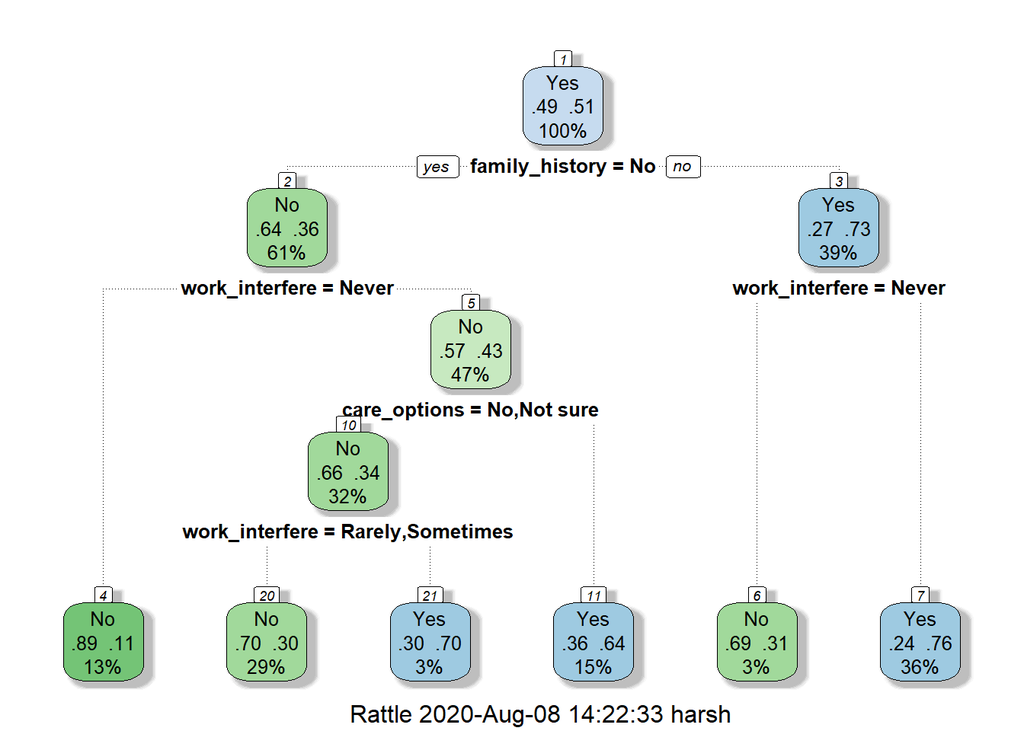

```r
#plotting the tree using fancyRpartPlot function
fancyRpartPlot(rpart_model)
```

```r
##Predicting the outcome of tuned model
pred_rpart_tuned <- predict(rpart_model, testing_data_factor)
pred_rpart_tuned <- as.factor(ifelse(pred_rpart_tuned[,2] < 0.5, "No", "Yes"))

#Model evaluation using confusionMatrix, Accuracy, RMSE, MAE, and AUC
confusionMatrix(pred_rpart_tuned,testing_data_factor$treatment)
```

```
## Confusion Matrix and Statistics
##
##           Reference
## Prediction  No Yes
##        No  120  27
##        Yes  35 132
##
##                Accuracy : 0.8025
##                  95% CI : (0.7542, 0.8451)
##     No Information Rate : 0.5064
##     P-Value [Acc > NIR] : <2e-16
##
##                   Kappa : 0.6048
##
##  Mcnemar's Test P-Value : 0.374
##
##             Sensitivity : 0.7742
##             Specificity : 0.8302
##          Pos Pred Value : 0.8163
##          Neg Pred Value : 0.7904
##              Prevalence : 0.4936
##          Detection Rate : 0.3822
##    Detection Prevalence : 0.4682
##       Balanced Accuracy : 0.8022
##
##        'Positive' Class : No
##
```

```r
accuracy_rpart_tuned <- accuracy(pred_rpart_tuned,testing_data_factor$treatment)
RMSE_rpart_tuned <- RMSE(as.numeric(testing_data_factor$treatment), as.numeric(pred_rpart_tuned))
MAE_rpart_tuned <- MAE(as.numeric(testing_data_factor$treatment), as.numeric(pred_rpart_tuned))
roc_rpart_tuned <- roc(as.numeric(testing_data_factor$treatment), as.numeric(pred_rpart_tuned))
```

### Comparison of models

- For Comparison, plot of accuracy and other metric are shown below
- It is observed from the plot that recursive partition models performs the best amongst the others
- Recursive partition has the best accuracy along with the lowest RMSE and MAE error compared to other models
- Separate dataframe is created for MAE, RMSE and AUC values of each model

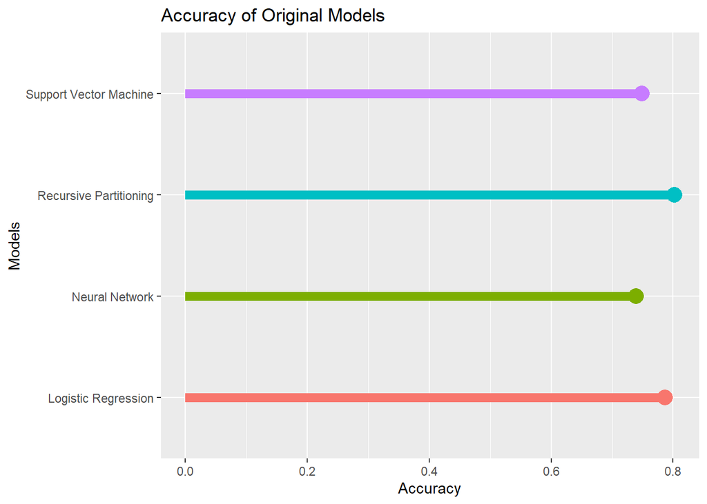

```r
############################
### Comparison of models ###
############################

#Creating a dataframe of model accuracy for comparison
comparison_acc <- data.frame(Models = c("Logistic Regression","Neural Network","Support Vector Machine","Recursive Partitioning"),
                         Original = c(accuracy_glm,accuracy_nn,accuracy_svm,accuracy_rpart),
                         Tuned = c(accuracy_glm_tuned,accuracy_nn_tuned,accuracy_svm_tuned,accuracy_rpart_tuned))

#Plotting the accuracies of the models
ggplot(data = comparison_acc, aes(x = Original, y = Models, color = Models, group = Models))+
  geom_segment(data = comparison_acc,aes(x=0,xend = Original, y = Models, yend = Models),size = 3)+
  geom_point(size = 5)+ggtitle("Accuracy of Original Models")+
  theme(legend.position = "none")+xlab("Accuracy")+ylab("Models")
```

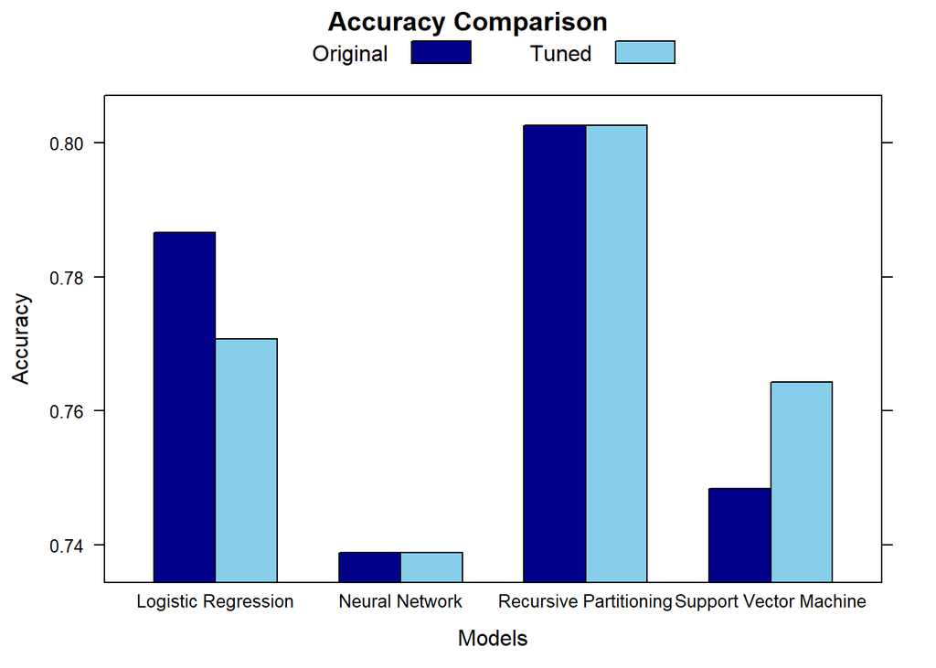

```r
#Comparing the accuracy of original and tuned models
colors = c('Darkblue', 'skyblue')
barchart(Original+Tuned~Models,data=comparison_acc,run=best,
         ylab = "Accuracy",
         xlab = "Models",
         scales=list(alternating=1),
         auto.key=list(space="top", columns=2,points=FALSE,
                       rectangles=TRUE, cex.title=1),
         par.settings=list(superpose.polygon=list(col=colors)),main = "Accuracy Comparison")
```

```r
#Comparing the model evaluation metrics of all the models
comparison <- data.frame(Models = c("Logistic Regression","Neural Network","Support Vector Machine","Recursive Partitioning"),
                         MAE = c(MAE_glm,MAE_nn,MAE_svm,MAE_rpart), RMSE = c(RMSE_glm,RMSE_nn,RMSE_svm,RMSE_rpart),
                         AUC = c(roc_glm$auc,roc_nn$auc,roc_svm$auc,roc_rpart$auc))
#Comparison Dataframe
comparison
```

| Models | MAE | RMSE | AUC |
| --- | --- | --- | --- |
| Logistic Regression | 0.2133758 | 0.4619262 | 0.7867113 |
| Neural Network | 0.2611465 | 0.5110249 | 0.7405153 |
| Support Vector Machine | 0.2515924 | 0.5015898 | 0.7488131 |
| Recursive Partitioning | 0.1974522 | 0.4443560 | 0.8021911 |

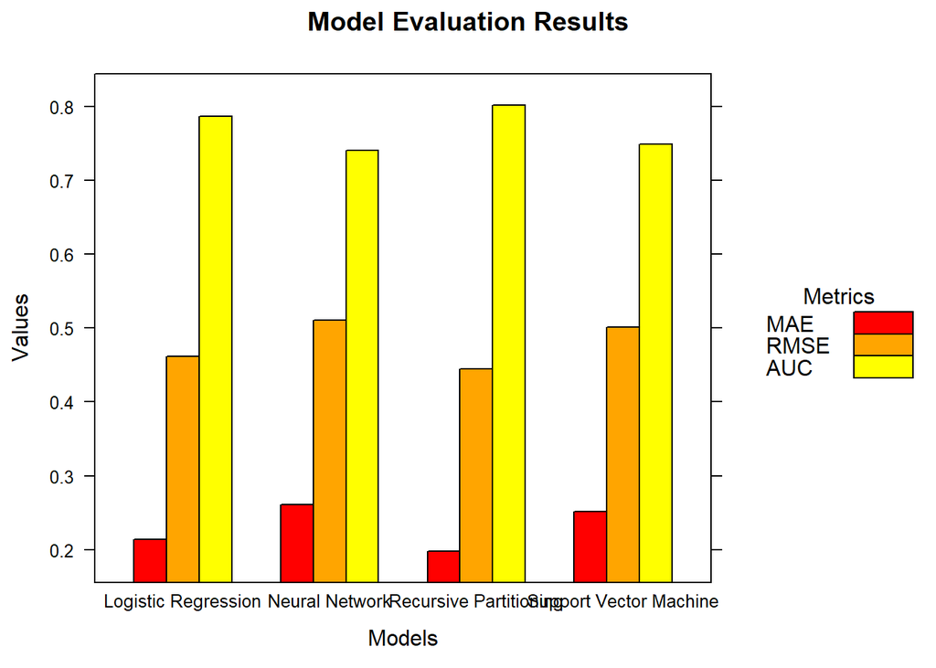

```r
#Plotting the comparison of model evaluation metrics of all the models
colors = c('red', 'orange', 'yellow')
barchart(MAE+RMSE+AUC~Models,data=comparison,run=best,
         ylab = "Values",
         xlab = "Models",scales=list(alternating=1),
         auto.key=list(space='right', rows=3,points=FALSE,
                       rectangles=TRUE,title="Metrics", cex.title=1),
         par.settings=list(superpose.polygon=list(col=colors)),main="Model Evaluation Results")
```

### Construction of ensemble model

- Stack learner from caretEnsemble is used to build a stacked ensemble model
- For base model, I have used rpart, glm and svmRadial algorithms
- For the final stack learner, I have used glm i.e logistic regression
- Each model from base make individual predictions and final predictions is done from these outcomes using logistic regression
- Comparison of ensemble model with other model is also shown using a bar chart
- It is observed that accuracy of ensemble model is lesser compared to decision trees

```r
######################################
### Construction of ensemble model ###
######################################

#Using train function from caret package to
#create a base model which consist 3 models
control <- trainControl(method="repeatedcv", number=10, repeats=3, savePredictions="all", classProbs=TRUE)
algorithmList <- c('rpart', 'glm', 'svmRadial')
set.seed(101)

#Training the models using training dataset
models <- caretList(treatment~., data=training_data_factor, trControl=control, methodList=algorithmList)
results <- resamples(models)

#Observing the results using summary and dotplot
summary(results)
```

```
##
## Call:
## summary.resamples(object = results)
##
## Models: rpart, glm, svmRadial
## Number of resamples: 30
##
## Accuracy
##                Min.   1st Qu.    Median      Mean   3rd Qu.      Max. NA's
## rpart     0.6063830 0.6649216 0.6808511 0.6856636 0.7150336 0.7473684    0
## glm       0.6315789 0.7127660 0.7301792 0.7262126 0.7466965 0.7894737    0
## svmRadial 0.6702128 0.7263158 0.7368421 0.7399940 0.7572508 0.8000000    0
##
## Kappa
##                Min.   1st Qu.    Median      Mean   3rd Qu.      Max. NA's
## rpart     0.2091860 0.3285150 0.3627103 0.3704482 0.4280035 0.4937833    0
## glm       0.2625859 0.4255319 0.4604493 0.4523922 0.4933561 0.5790873    0
## svmRadial 0.3416177 0.4523889 0.4737424 0.4800114 0.5148224 0.6002215    0
```

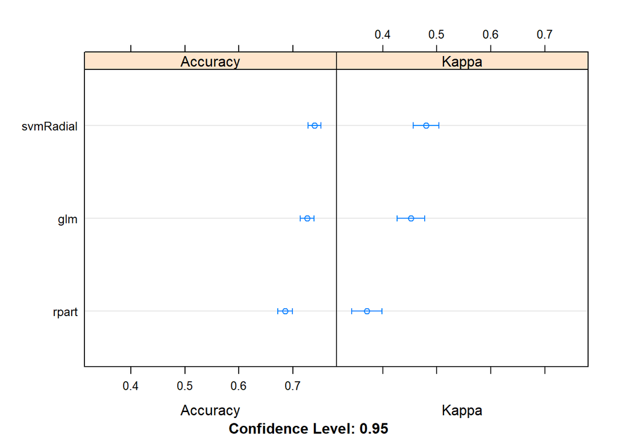

```r
dotplot(results)
```

```r
#Creating a new traincontrol method for final stage of the stack learner
stackControl <- trainControl(method="repeatedcv", number=10, repeats=3, savePredictions="all", classProbs=TRUE)
set.seed(101)

# Using glm at the final stage of the stack learner
stack.glm <- caretStack(models, method="glm", metric="Accuracy", trControl=stackControl)

#Printing the accuracy of the model
print(stack.glm)
```

```
## A glm ensemble of 3 base models: rpart, glm, svmRadial
##
## Ensemble results:
## Generalized Linear Model
##
## 2835 samples
##    3 predictor
##    2 classes: 'No', 'Yes'
##
## No pre-processing
## Resampling: Cross-Validated (10 fold, repeated 3 times)
## Summary of sample sizes: 2552, 2551, 2552, 2552, 2552, 2552, ...
## Resampling results:
##
##   Accuracy   Kappa
##   0.7412185  0.4823754
```

```r
#Predicting the outcome for the stack ensemble learner
pred_ensemble <- predict(stack.glm, testing_data_factor)

#Model evaluation using confusionMatrix, Accuracy, RMSE, MAE, and AUC
confusionMatrix(pred_ensemble,testing_data_factor$treatment)
```

```
## Confusion Matrix and Statistics
##
##           Reference
## Prediction  No Yes
##        No  118  35
##        Yes  37 124
##
##                Accuracy : 0.7707
##                  95% CI : (0.7202, 0.816)
##     No Information Rate : 0.5064
##     P-Value [Acc > NIR] : <2e-16
##
##                   Kappa : 0.5413
##
##  Mcnemar's Test P-Value : 0.9062
##
##             Sensitivity : 0.7613
##             Specificity : 0.7799
##          Pos Pred Value : 0.7712
##          Neg Pred Value : 0.7702
##              Prevalence : 0.4936
##          Detection Rate : 0.3758
##    Detection Prevalence : 0.4873
##       Balanced Accuracy : 0.7706
##
##        'Positive' Class : No
##
```

```r
accuracy_ensemble <- accuracy(pred_ensemble,testing_data_factor$treatment)
RMSE_ensemble <- RMSE(as.numeric(testing_data_factor$treatment), as.numeric(pred_ensemble))
MAE_ensemble <- MAE(as.numeric(testing_data_factor$treatment), as.numeric(pred_ensemble))
roc_ensemble <- roc(as.numeric(testing_data_factor$treatment), as.numeric(pred_ensemble))

#Comparing the model evaluation metrics of all the models
comparison_new <- data.frame(Models = c("Logistic Regression","Neural Network","Support Vector Machine",
                                        "Recursive Partitioning","Ensemble Model"),
                         MAE = c(MAE_glm,MAE_nn,MAE_svm,MAE_rpart,MAE_ensemble),
                         RMSE = c(RMSE_glm,RMSE_nn,RMSE_svm,RMSE_rpart,RMSE_ensemble),
                         AUC = c(roc_glm$auc,roc_nn$auc,roc_svm$auc,roc_rpart$auc,roc_ensemble$auc))
#Comparison Dataframe
comparison_new
```

| Models | MAE | RMSE | AUC |
| --- | --- | --- | --- |
| Logistic Regression | 0.2133758 | 0.4619262 | 0.7867113 |
| Neural Network | 0.2611465 | 0.5110249 | 0.7405153 |
| Support Vector Machine | 0.2515924 | 0.5015898 | 0.7488131 |
| Recursive Partitioning | 0.1974522 | 0.4443560 | 0.8021911 |
| Ensemble Model | 0.2292994 | 0.4788521 | 0.7705823 |

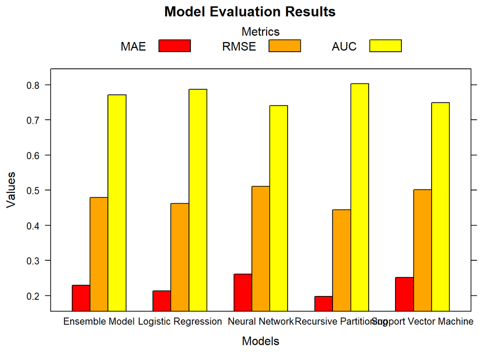

```r
#Plotting the comparison of model evaluation metrics of all the models
colors = c('red', 'orange', 'yellow')
barchart(MAE+RMSE+AUC~Models,data=comparison_new,run=best,
         ylab = "Values",
         xlab = "Models",scales=list(alternating=1),
         auto.key=list(space='top', columns=3,points=FALSE,
                       rectangles=TRUE,title="Metrics", cex.title=1),
         par.settings=list(superpose.polygon=list(col=colors)),main="Model Evaluation Results")
```

### Model Deployment

- For model deployment, I have used neural network model and stored it in a rds file
- This .rds file is used in RShiny app to make predictions
- I have deployed the RShiny app using Heroku

```r
#RDS File for Shiny R app
saveRDS(neuralnet_model,'model.rds')
```

- A wordcloud is built using the comments feature to see what most of the professional felt like sharing

```r
#Getting comments from the survey
comments <- data[,27]
comments1 <-  comments[!is.na(comments)]
comments_corpus <- Corpus(VectorSource(comments1))
#We can observe total documents using print
print(comments_corpus)
```

```
## <<SimpleCorpus>>
## Metadata:  corpus specific: 1, document level (indexed): 0
## Content:  documents: 164
```

```r
#To observe the content we use inspect() function
inspect(comments_corpus[1:2])
```

```
## <<SimpleCorpus>>
## Metadata:  corpus specific: 1, document level (indexed): 0
## Content:  documents: 2
##
## [1] I'm not on my company's health insurance which could be part of the reason I answered Don't know to so many questions.
## [2] I have chronic low-level neurological issues that have mental health side effects. One of my supervisors has also experienced similar neurological problems so I feel more comfortable being open about my issues than I would with someone without that experience.
```

```r
#We remove all the numbers and punctuations using tm_map() function. It is used to transform data.
corpus_clean <- tm_map(comments_corpus, tolower)
corpus_clean <- tm_map(corpus_clean, removeNumbers)
corpus_clean <- tm_map(corpus_clean, removeWords, stopwords())
corpus_clean <- tm_map(corpus_clean, removePunctuation)
corpus_clean <- tm_map(corpus_clean, stripWhitespace)
#We verify using inspect whether all unwanted characters are removed
inspect(corpus_clean[1:2])
```

```
## <<SimpleCorpus>>
## Metadata:  corpus specific: 1, document level (indexed): 0
## Content:  documents: 2
##
## [1]  companys health insurance part reason answered know many questions
## [2]  chronic lowlevel neurological issues mental health side effects one supervisors also experienced similar neurological problems feel comfortable open issues someone without experience
```

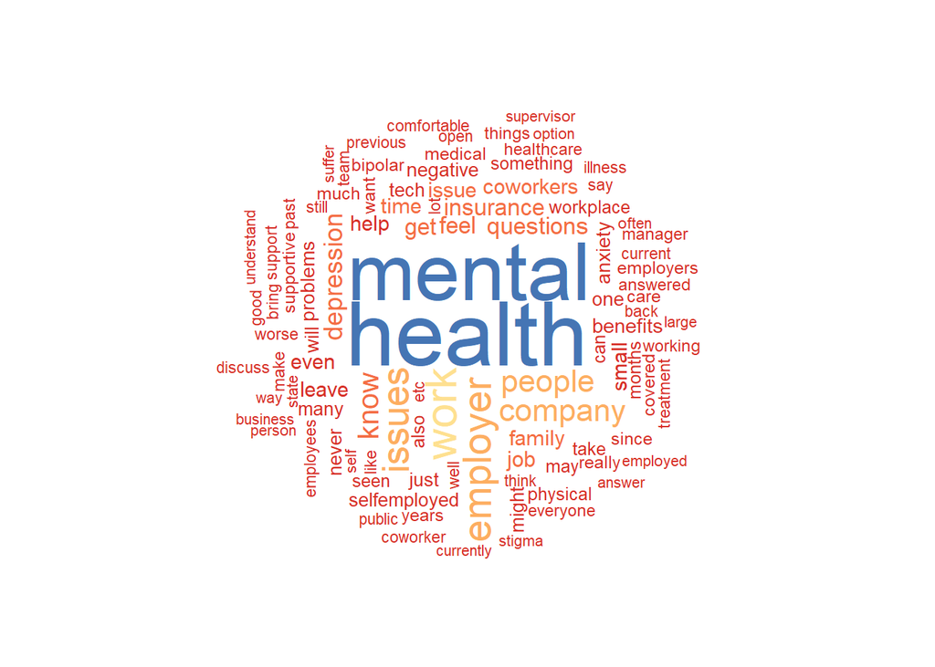

```r
#Using wordcloud to see most common words used in comments of the survey
wordcloud(corpus_clean,max.words=100 ,random.order=FALSE,rot.per=0.35,colors=brewer.pal(8,"RdYlBu"))
```